# Red Wine Quality Exploration by Qiliang Huang

# 双变量绘图选择

```
##                          X fixed.acidity volatile.acidity citric.acid
## X                     1.00         -0.27            -0.01       -0.15
## fixed.acidity        -0.27          1.00            -0.26        0.67
## volatile.acidity     -0.01         -0.26             1.00       -0.55
## citric.acid          -0.15          0.67            -0.55        1.00
## residual.sugar       -0.03          0.11             0.00        0.14
## chlorides            -0.12          0.09             0.06        0.20
## free.sulfur.dioxide   0.09         -0.15            -0.01       -0.06
## total.sulfur.dioxide -0.12         -0.11             0.08        0.04
## density              -0.37          0.67             0.02        0.36
## pH                    0.14         -0.68             0.23       -0.54
## sulphates            -0.13          0.18            -0.26        0.31
## alcohol               0.25         -0.06            -0.20        0.11
## quality               0.07          0.12            -0.39        0.23
##                      residual.sugar chlorides free.sulfur.dioxide
## X                             -0.03     -0.12                0.09
## fixed.acidity                  0.11      0.09               -0.15
## volatile.acidity               0.00      0.06               -0.01
## citric.acid                    0.14      0.20               -0.06
## residual.sugar                 1.00      0.06                0.19
## chlorides                      0.06      1.00                0.01
## free.sulfur.dioxide            0.19      0.01                1.00
## total.sulfur.dioxide           0.20      0.05                0.67
## density                        0.36      0.20               -0.02
## pH                            -0.09     -0.27                0.07
## sulphates                      0.01      0.37                0.05
## alcohol                        0.04     -0.22               -0.07
## quality                        0.01     -0.13               -0.05
##                      total.sulfur.dioxide density    pH sulphates alcohol
## X                                   -0.12   -0.37  0.14     -0.13    0.25
## fixed.acidity                       -0.11    0.67 -0.68      0.18   -0.06
## volatile.acidity                     0.08    0.02  0.23     -0.26   -0.20
## citric.acid                          0.04    0.36 -0.54      0.31    0.11
## residual.sugar                       0.20    0.36 -0.09      0.01    0.04
## chlorides                            0.05    0.20 -0.27      0.37   -0.22
## free.sulfur.dioxide                  0.67   -0.02  0.07      0.05   -0.07
## total.sulfur.dioxide                 1.00    0.07 -0.07      0.04   -0.21
## density                              0.07    1.00 -0.34      0.15   -0.50
## pH                                  -0.07   -0.34  1.00     -0.20    0.21
## sulphates                            0.04    0.15 -0.20      1.00    0.09
## alcohol                             -0.21   -0.50  0.21      0.09    1.00
## quality                             -0.19   -0.17 -0.06      0.25    0.48
##                      quality
## X                       0.07
## fixed.acidity           0.12
## volatile.acidity       -0.39
## citric.acid             0.23
## residual.sugar          0.01
## chlorides              -0.13
## free.sulfur.dioxide    -0.05
## total.sulfur.dioxide   -0.19
## density                -0.17
## pH                     -0.06
## sulphates               0.25
## alcohol                 0.48
## quality                 1.00
```

### 快速生成大量相关图表

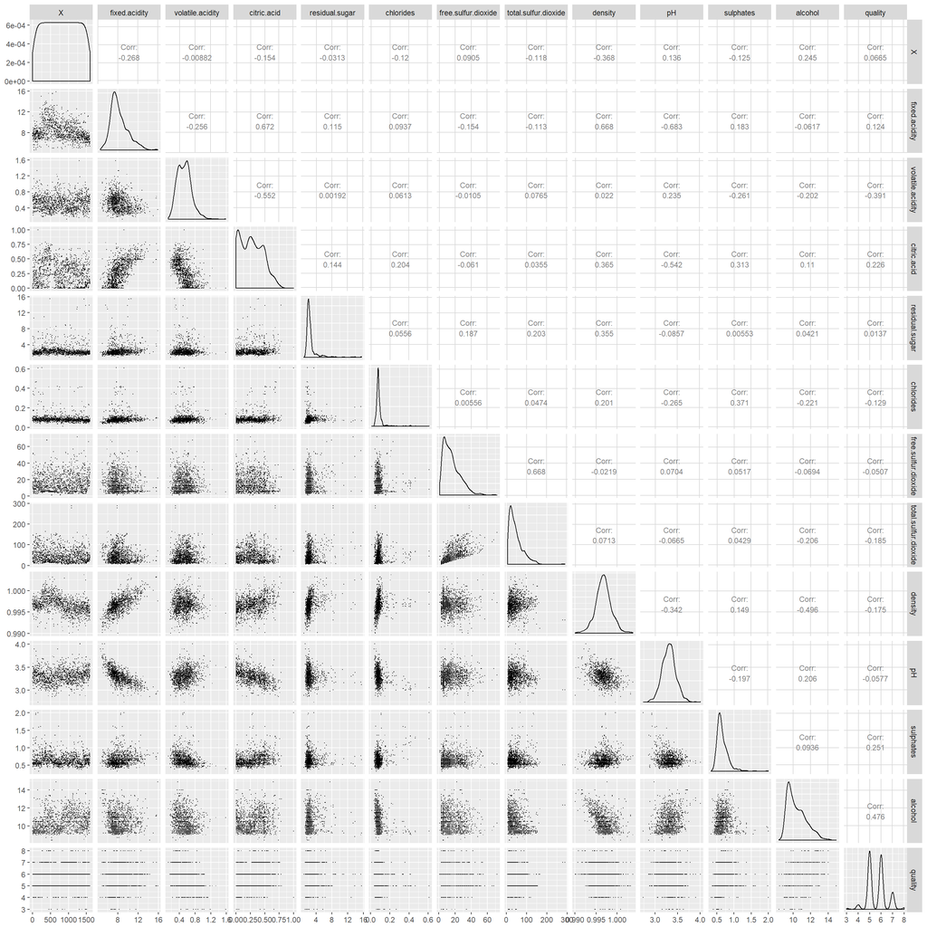

### 箱型图+散点图 质量、酒精度

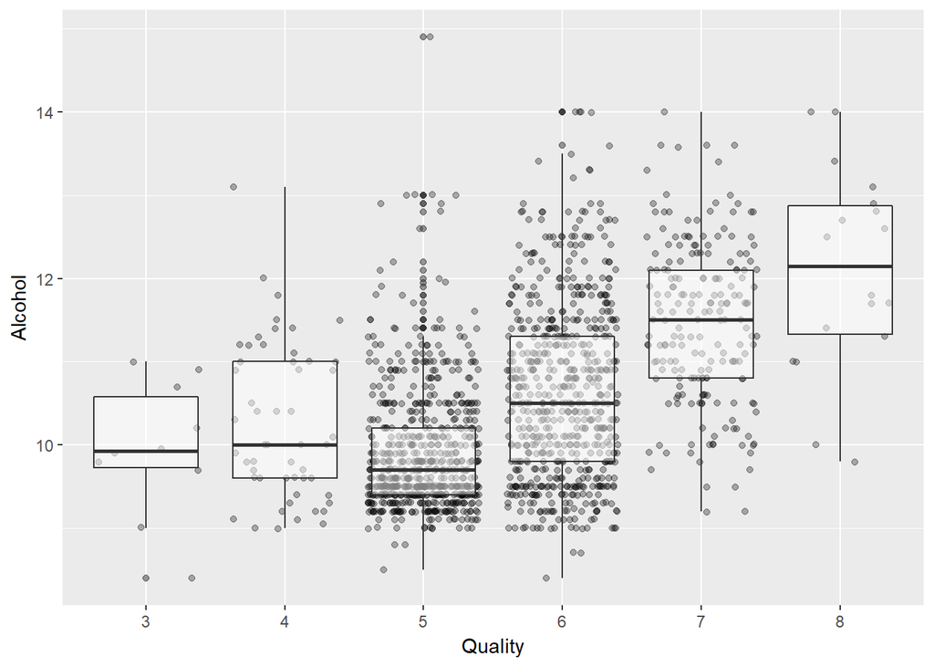

### 酒精度、质量

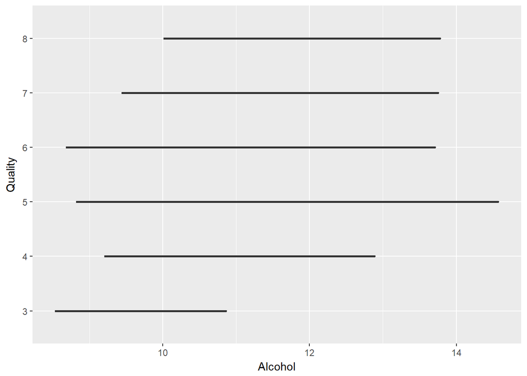

反过来绘图行不通，因为酒精度是连续的变量。

### 箱型图 质量、挥发性酸含量

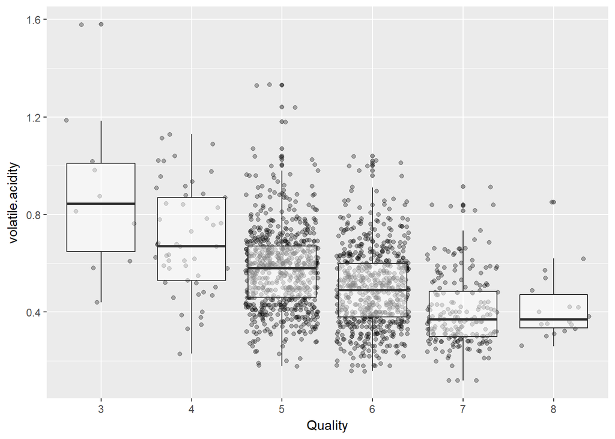

### 不挥发性酸 vs 质量

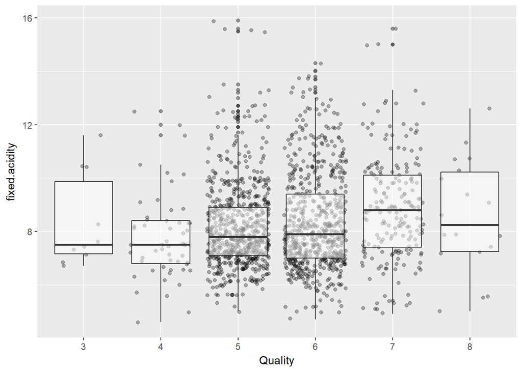

不挥发性酸和质量没有明显的关系。

### 散点图 柠檬酸含量和不挥发性酸含量

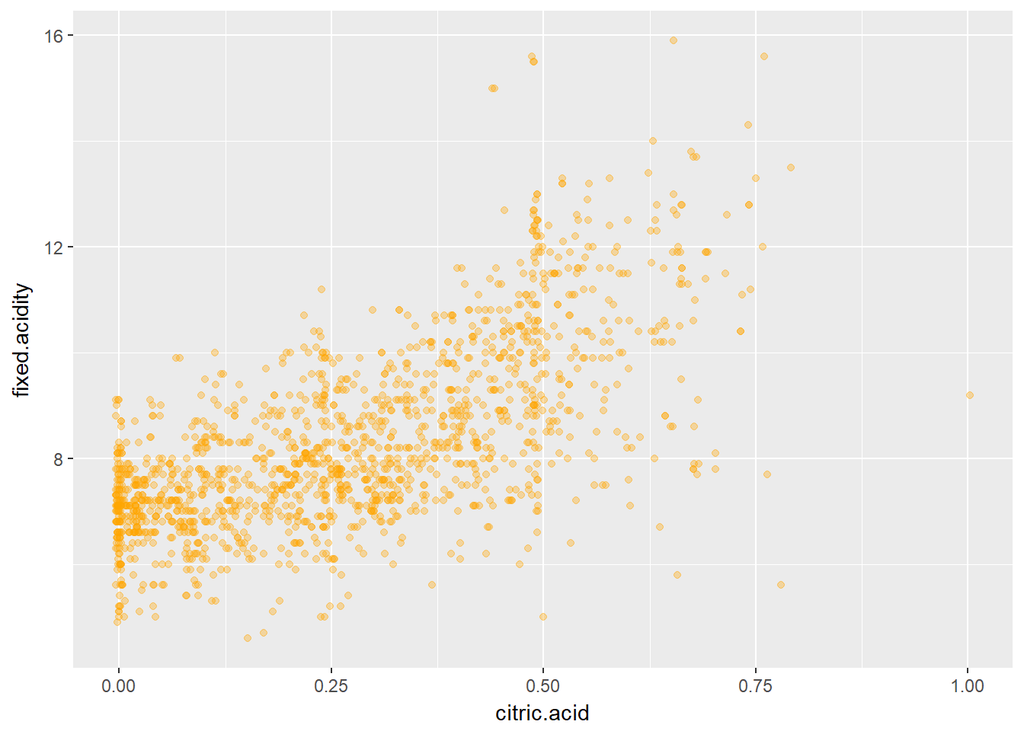

柠檬酸含量和不挥发性酸含量有比较强的正向相关关系，可能不挥发性酸的主要成分就是柠檬酸。

### 散点图 柠檬酸含量和挥发性酸

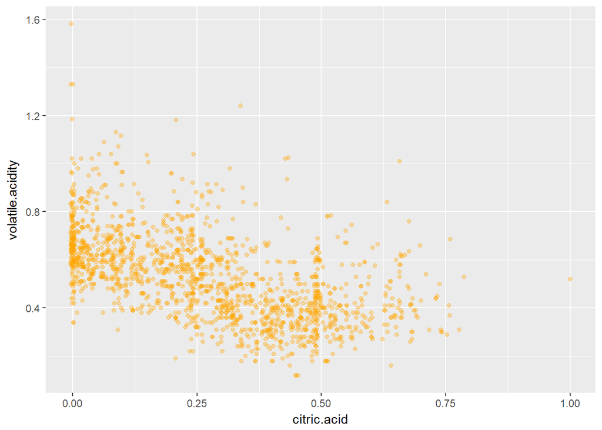

### 散点图 挥发性酸和不挥发性酸

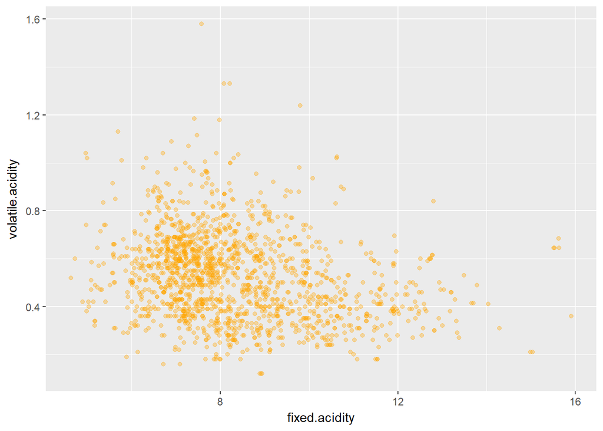

挥发性酸和不挥发性酸含量间并没有明显的相关关系。

### 不挥发性酸和密度

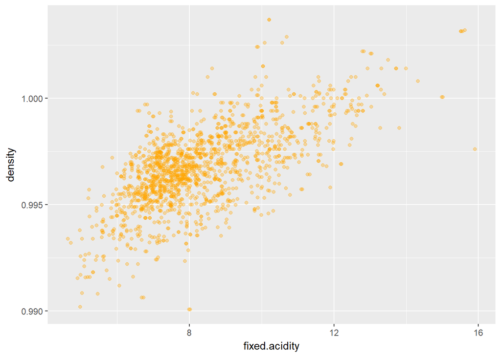

不挥发性酸和密度之间有很强的相关关系。

### 密度和质量

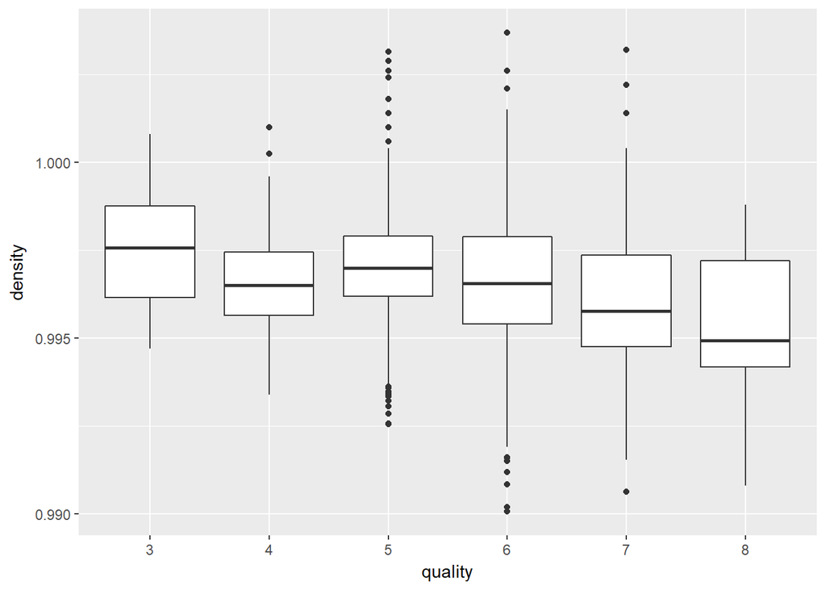

### 不挥发性酸和质量

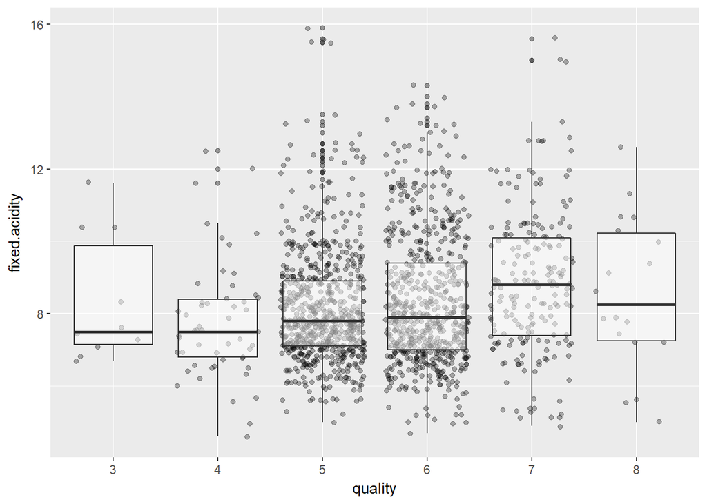

### 不挥发性酸和pH值

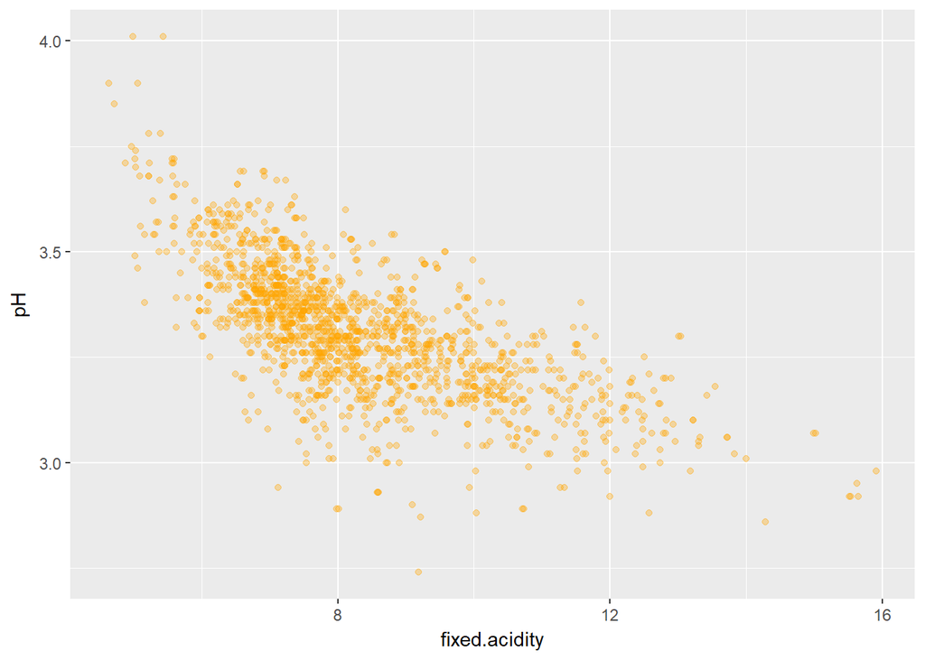

不挥发性酸和pH值，很强的负相关关系。

### 质量和pH值

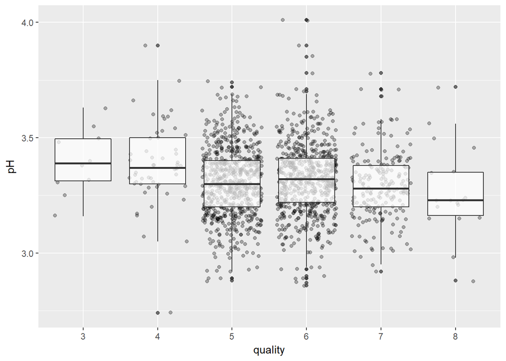

质量和pH值有很微弱的负相关关系; 质量和不挥发性酸含量有很微弱的正相关关系。

# 双变量分析

### 探讨你在这部分探究中观察到的一些关系。这些感兴趣的特性与数据集内其他特性有什么区别？

参考：https://zh.wikipedia.org/wiki/%E8%91%A1%E8%90%84%E9%85%92%E4%B8%AD%E7%9A%84%E9%85%B8

### 你发现最强的关系是什么？

# 多变量绘图选择

### 酒精度、质量和挥发性酸度

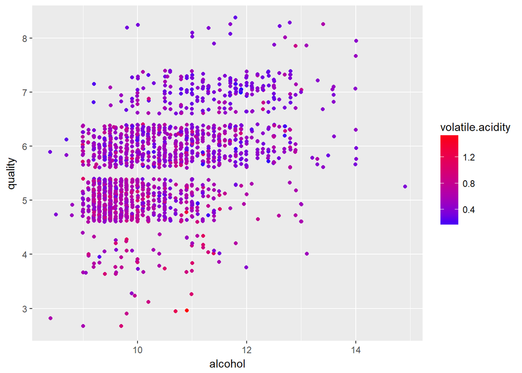

没有发现明显特征。

### 酒精度质量和柠檬酸度

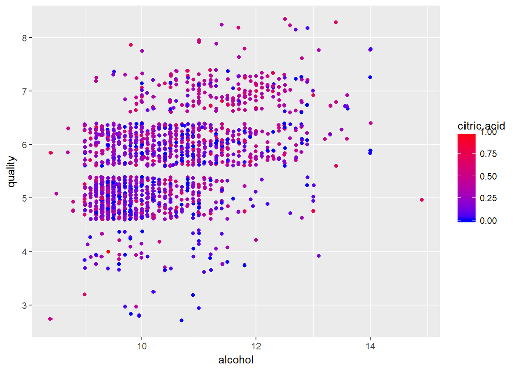

没有发现明显特征。

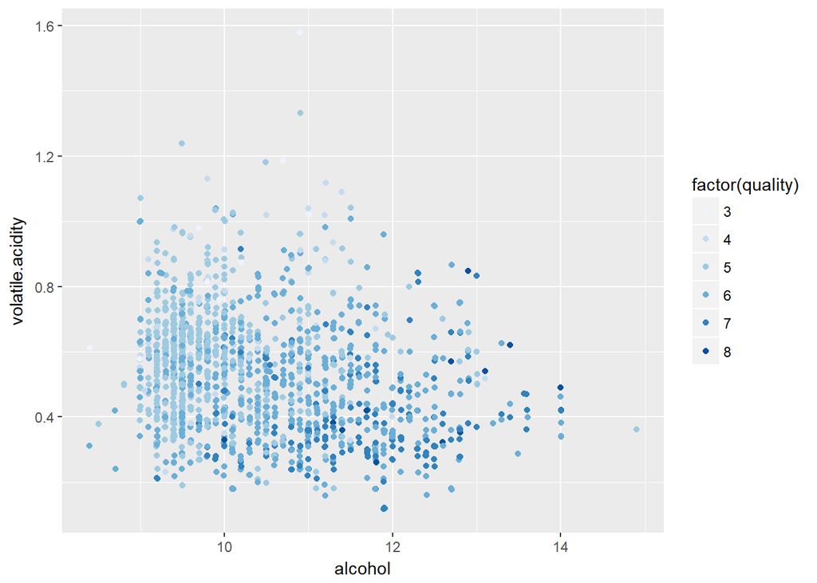

似乎高质量的葡萄酒挥发性酸含量要低一些，酒精度要高一些。

### 酒精度、密度、剩余糖度

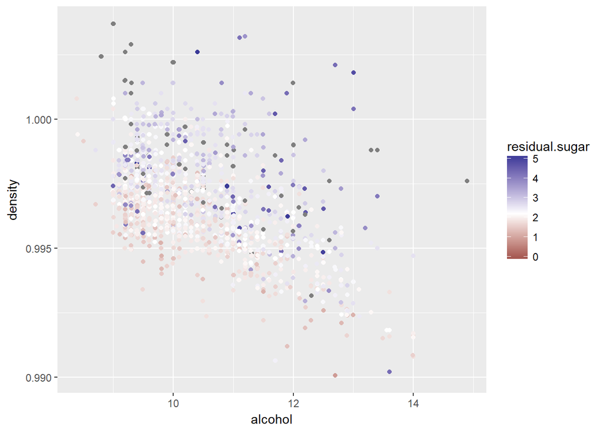

没有明显的组合特征。

### 密度、pH值、质量

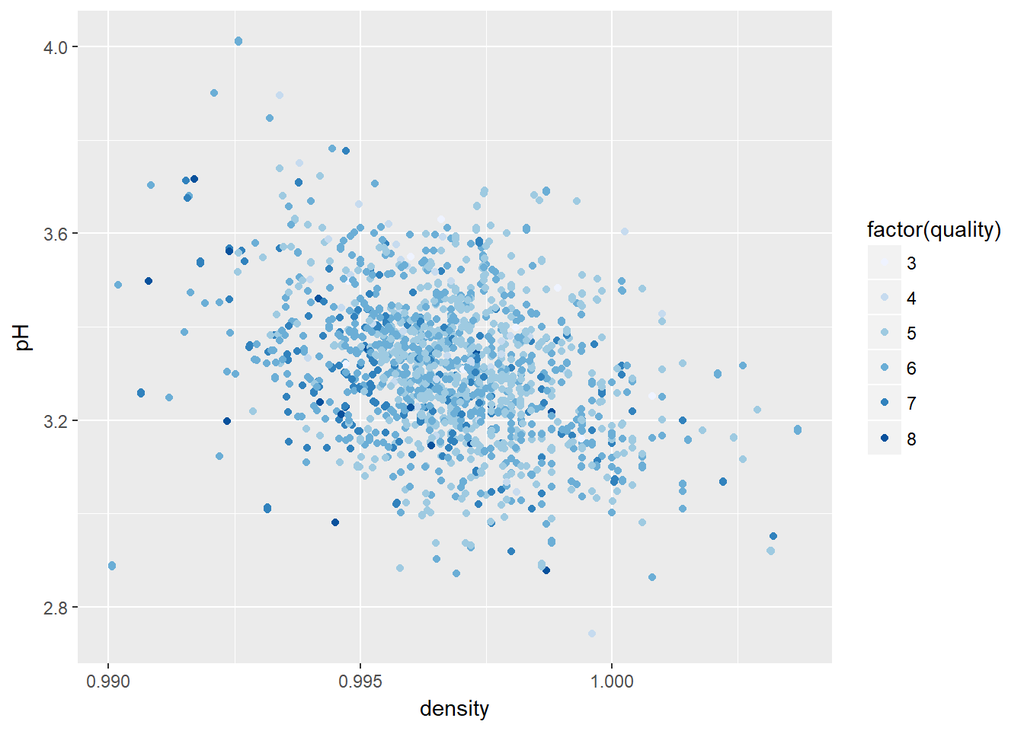

没有明显的组合特征。

# 多变量分析

### 探讨你在这部分探究中观察到的一些关系。通过观察感兴趣的特性，是否存在相互促进的特性？

只有在最后一中发现随着酒精度的提高，挥发性酸含量逐渐下降，酒的质量逐渐变好，但关系都很微弱。

### 这些特性之间是否存在有趣或惊人的联系呢？

没有。

### 选项：你是否创建过数据集的任何模型？讨论你模型的优缺点。

# 定稿图与总结

### 绘图一

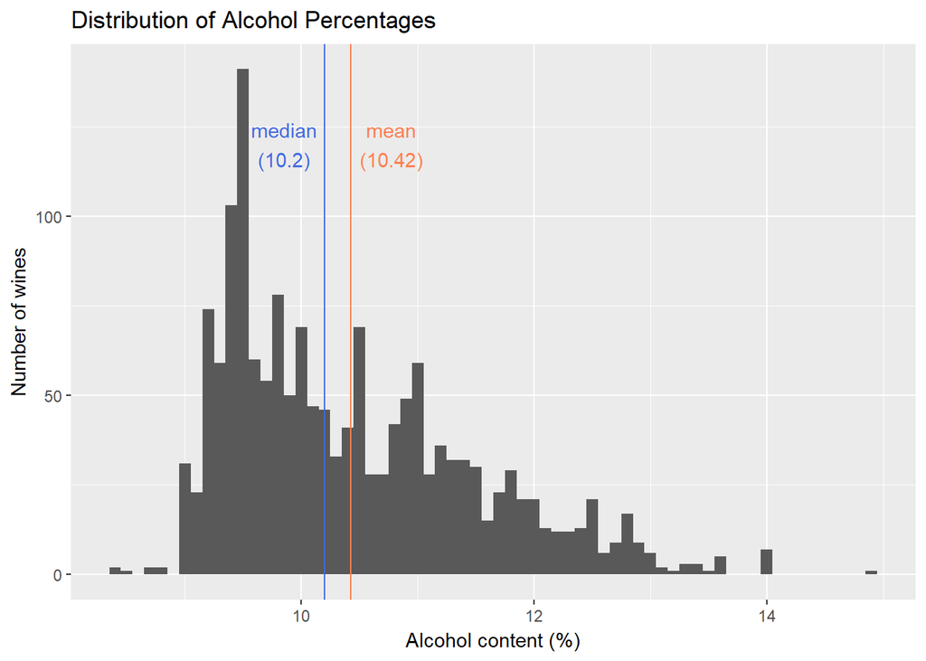

### 描述一

酒精含量呈现右偏分布，右侧具有长尾，而且均值要比中位数大。 绝大多数葡萄酒酒精的含量都在9-12度以内。